# Session 1

Global landscape of data governance institutions and frameworks

[Ernest Guevarra](https://ernest.guevarra.io)

ernest@guevarra.io

[University of Oxford](https://www.tropicalmedicine.ox.ac.uk/study-with-us/msc-ihtm)

## Definitions

## What is data?

“When we refer to data, we mean information about **people**, **things** and **systems**. … Data about people can include **personal data**, such as *basic contact details*, records generated through *interaction with services* or the *web*, or information about their *physical characteristics (biometrics)* - and it can also extend to **population-level data**, such as *demographics*. Data can also be about **systems and infrastructure**, such as *administrative records* about businesses and public services. Data is increasingly used to describe **location**, such as *geospatial reference* details, and the *environment* we live in, such as data about *biodiversity* or the *weather*. It can also refer to the information generated by the *burgeoning web of sensors* that make up the *Internet of Things*.”

```
                                                 - UK National Data Strategy
```

## What is data governance?

A system of **robust legal frameworks**, **ethical guidelines**, **standards**, and **processes** that ensures an organisation’s data is **accurate**, **consistent**, **secure**, and **compliant** throughout its lifecycle.

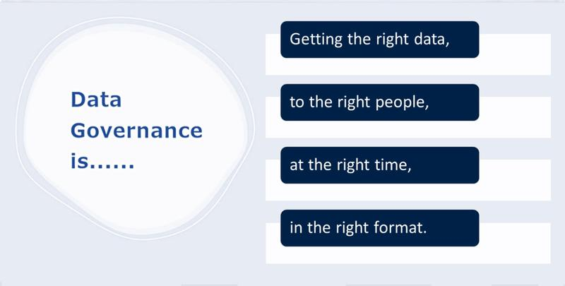

## What is the data lifecycle?

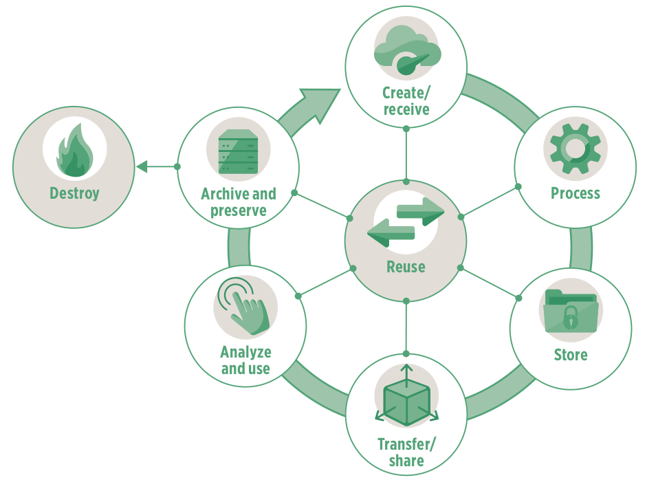

## Public vs Private intent data

### Public intent data

- Public intent data is data collected for public purposes.
- Public intent data is a foundation of public policies and can play a transformative role in the public sector.

### Private intent data

- Private intent data is data collected by the private sector as part of routine business processes.
- Private intent data can drive innovation, lower transaction costs, and improve productivity, competitiveness, and economic growth.

## Activity 1: Tell me about your data

## Activty 1 - Mechanics

1. Move into the group assigned to you.
   - TAMRI Hanoi + TAMRI Ho Chi Minh City
   - Tam Anh Ho Chi Minh City
   - Tam Anh Hanoi
   - Eplus + SMART Research
   - VNVC + Calif
   - Department of Health (Hanoi and Ho Chi Minh City) + Department of Science and Technology Hanoi

## Activity 1 - Mechanics

2. Individually, write keywords and/or key terms/concepts that describe any one or all data that you work with and/or are in charge of
   - write on the provided meta cards;
   - use keywords or key phrases and not sentences;
   - one keyword or key phrase in one meta card;
   - you can use as many meta cards as you want/need.

## Activity 1 - Mechanics

3. Post your meta cards onto the assigned wall or table for your group.
   - Make sure that your meta cards are separate from everyone else’s in your group;
   - Make sure that your meta cards are posted in such a way that the text in each card is readable (don’t make the cards overlap).

## Activity 1 - Mechanics

4. Within your group, find a partner and discuss and describe with each other the data that you work with and/or are in charge of
   - You will be given 5 minutes to share with your partner;
   - After 5 minutes, find a new partner and then discuss and describe with each other;
   - We will do three rounds of partner discussion within group.

## Activty 1 - Mechanics

5. With another group, find a partner in that group and then ask them to discuss and describe to you the data they work with and/or in charge of
   - Specific groups will be chosen to approach another group;
   - The members of the visiting group will find a partner in the hosting group;
   - The members of the visiting group will ask their partner from the hosting group about the data they work with and/or are in charge of. They will have about 5 minutes for this discussion;
   - After five minutes, the members of the visiting group should find a new partner among the members of the hosting group and then start asking about the data they work with and/or are in charge of;
   - After three rounds, the hosting group will then be asked to visit another group and do the same steps while the visiting group will then host a different group.

## Public intent data

## Types of public intent data

- Administrative data
- Census data
- Sample surveys
- Citizen-generated data
- Machine-generated data
- Geospatial data

## Maximising value of public intent data

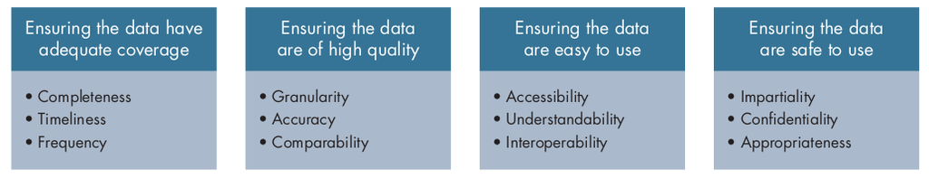

## Three pathways for public intent data to add value

- Improving service delivery
- Prioritising scarce resources
- Holding government accountable and empowering individuals

## Gaps in public intent data

## Coverage is inadequate

- Lack of *timeliness*, *frequency*, and *completeness*.
- Large gaps in geospatial data in lower-income countries

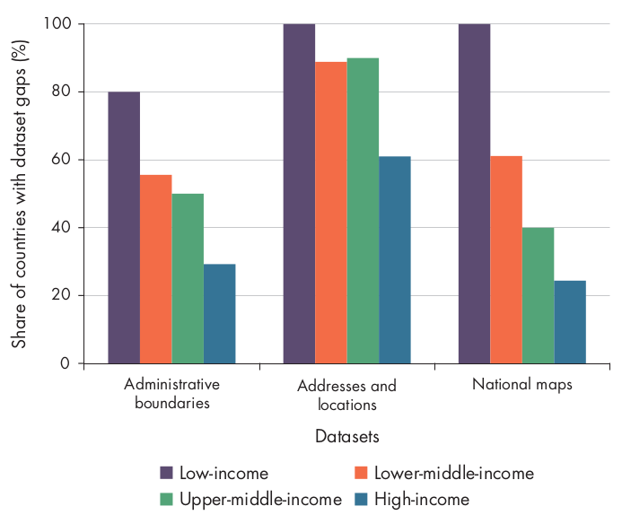

## Data quality is poor

- Lack of *granularity*, *accuracy*, and *comparability*.
- Lack of data disaggregation
- Lower-income countries have less comparable poverty data

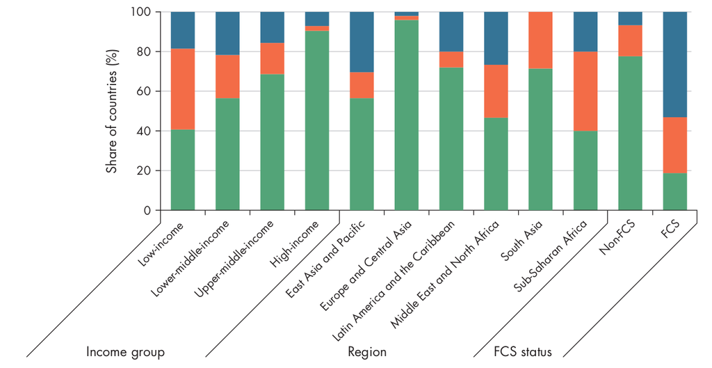

## Data not easy to use

- Lack of *accessibility*, *understandability*, and *interoperability*.

| **Indicator** | **Low-income** | **Low-middle-income** | **Upper-middle-income** | **High-income** |
| --- | --- | --- | --- | --- |
| Openness score (0–100) | 38 | 47 | 50 | 66 |
| Available in machine readable format (%) | 37 | 51 | 61 | 81 |
| Available in non-proprietary format (%) | 75 | 85 | 81 | 84 |
| Download options available (%) | 56 | 68 | 68 | 78 |
| Open terms of use/license (%) | 11 | 19 | 22 | 44 |

## Data not safe to use

- Data not immune to influence from stakeholders
- Data not stored securely - too common in government and private sector databases
- Data not properly de-identified

## Why gaps persist in public intent data

- Deficiencies in financing
- Deficiencies in technical capacity
- Deficiencies in governance
- Deficiencies in data demand

## Private intent data

## Data in the production process

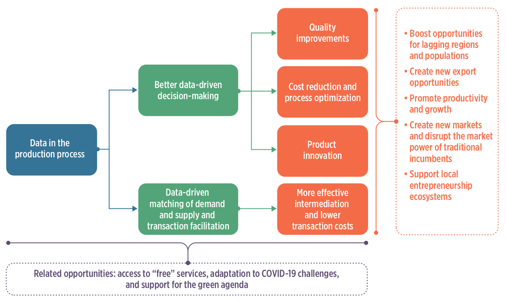

## Role of data in economic activity

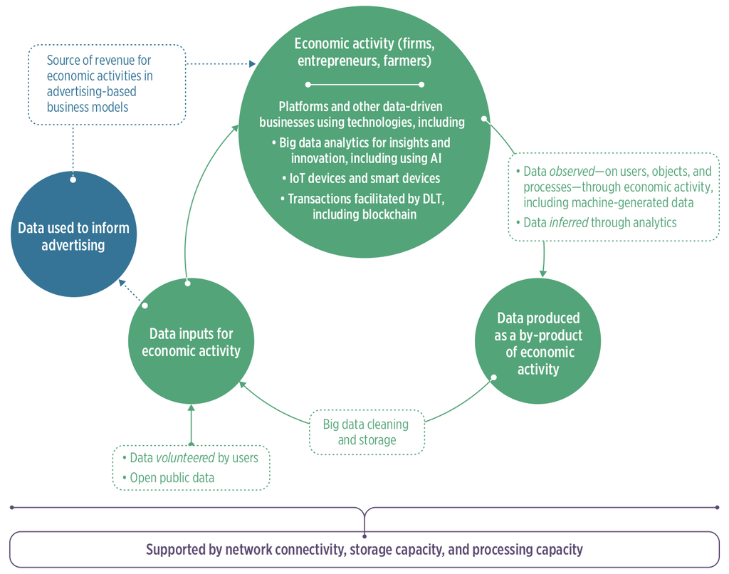

## Data inputs for economic activity

- Data collection by firms - **“digital footprint”**
- Use of public intent data by businesses

## Sectors transformed by use of data in the production process

- Finance
- Agriculture
- Health
- Education
- Transport and logistics

## Finance sector

- **Alternative credit scoring algorithms** - use of an individual’s digital footprint to train machine learning algorithms to identify, score, and underwrite credit.
- **Payment systems** - digital payments; mobile payments.
- **Use of transaction data for product development** - Mastercard’s Tourism Insights service allows leveraging big data to provide information on travellers’ preferences.
- **Distributed ledger technology** - blockchain; eliminates financial intermediaries; embedding rules into smart contracts simplifies negotiation and verification processes.

## Agriculture sector

- Remote sensing and geographic information systems - analysis of these data provide insights into farming operations; smart farming
- Internet-of-things (IoT) and embedded devices for monitoring farm and livestock conditions and farm operations
- Use of data to provide a range of services along the agriculture value chain
- Use of data to improve food traceability

## Education

- video conferencing/video communication tools
- digital supplemental learning platforms
- intelligent adaptive education

## Transport and logistics sector

- Digital freight matching
- Digital courier logistics
- IoT-enabled cold chain

## Risks to market structure from platform firms

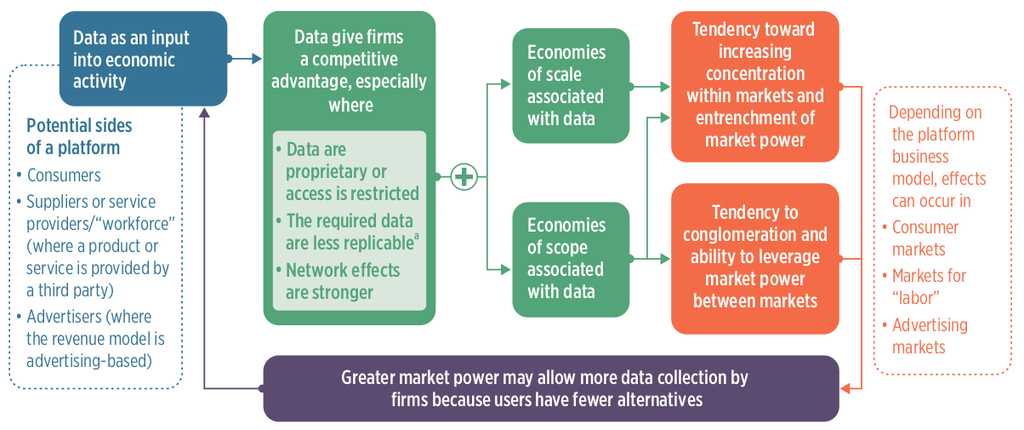

## Risks and adverse outcomes of data-driven businesses

- Increase propensity of dominant firms emerging
- Potential for exploitation of individuals
- Potential to increase inequality within and among countries